# Absorbances Second Project

ContextBase, http://contextbase.github.io

John Akwei, ECMp ERMp Data Scientist

January 26, 2016

# Synopsis

This document is the second analysis of absorbance data involving E.Coli and S.Aureus. Via Data Science analysis, (using the R programming language), the document author intends to build an understanding, numerically and statistically, of the difference between the samples, with p-values, t-tests, etc.

The dataset examined is: Make_Graphs_and_Statistics.docx

The data is re-formatted, in order that each row is a separate record, and the first row contains the variable names.

The free, open source application RStudio, (version 0.98.1103), was used for the analysis. The version of the R programming language used was, R version 3.2.0 (2015-04-16). The PC operating system is Windows 8.1.

#### Processing Requirements

```r
setwd("C:/Users/johnakwei/Dropbox/Programming/Morphotypes")
if (!require("ggplot2")) {install.packages("ggplot2"); require("ggplot2")}
```

# Data Input

```r
absorbances2nd <- read.csv("Second_Absorbances_Project.csv", header=T)
data1 <- subset(absorbances2nd, absorbances2nd$Graph=="Graph 1")
data2 <- subset(absorbances2nd, absorbances2nd$Graph=="Graph 2")
data3 <- subset(absorbances2nd, absorbances2nd$Graph=="Graph 3")
data1 <- data1[,1:4]
data1$Absorbance_E_Coli <- as.numeric(data1$Absorbance_E_Coli)
data2$Absorbance_E_Coli <- as.numeric(data2$Absorbance_E_Coli)
data2$Absorbance_S_Aureus <- as.numeric(data2$Absorbance_S_Aureus)
data3$Absorbance_E_Coli <- as.numeric(data3$Absorbance_E_Coli)
data3$Absorbance_S_Aureus <- as.numeric(data3$Absorbance_S_Aureus)
```

# Dataset 2 - Graphs, Linear Regression, Correlation, and T-Tests

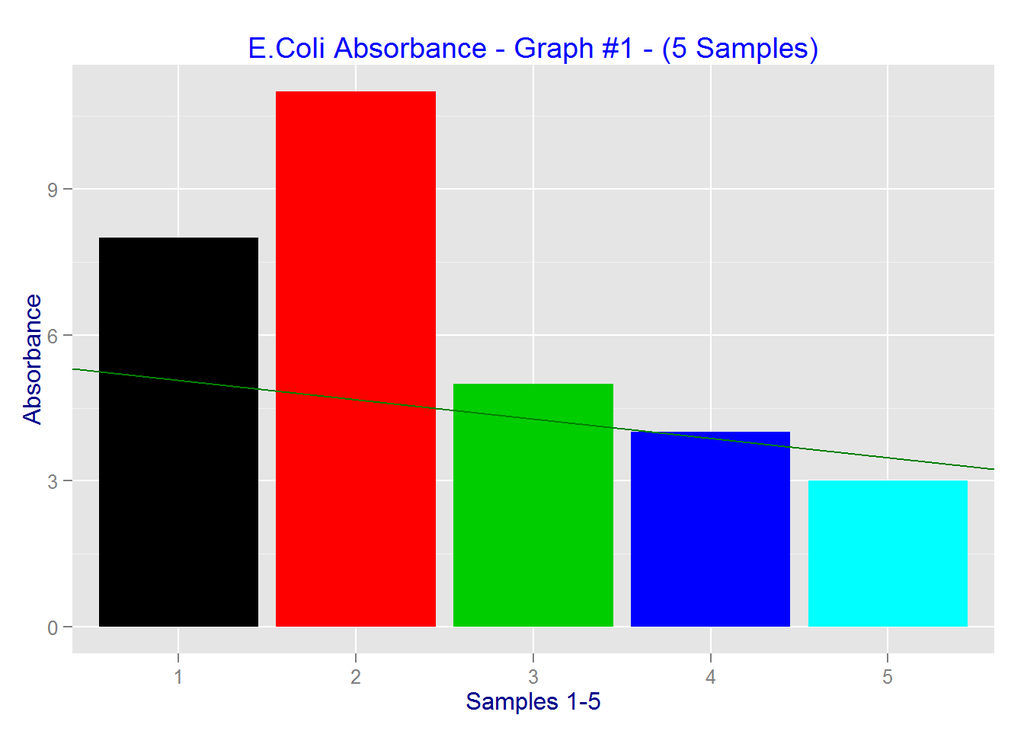

```r
absorbanceHigh <- data1$Absorbance_E_Coli + data1$Accuracy_E_Coli
absorbanceLow <- data1$Absorbance_E_Coli - data1$Accuracy_E_Coli

rLine <- coef(lm(data1$Material~data1$Absorbance_E_Coli, data=data1))
ggplot(data1, aes(x=as.factor(data1$Material),
                        y=data1$Absorbance_E_Coli)) +
geom_bar(aes(), stat="identity", fill=data1$Material) +
ggtitle("E.Coli Absorbance - Graph #1 - (5 Samples)") +
xlab("Samples 1-5") + ylab("Absorbance") +
theme(plot.title=element_text(color="blue")) +
theme(axis.title=element_text(color="darkblue")) +
geom_abline(intercept=rLine[1], slope=rLine[2], col="#008000")
```

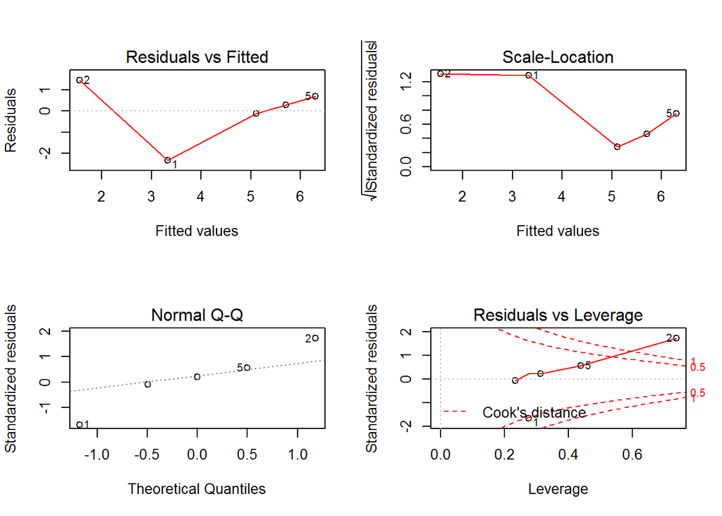

```r
fit <- lm(as.numeric(data1$Material)~data1$Absorbance_E_Coli, na.rm=T)
layout(matrix(c(1,2,3,4),2,2))
plot(fit)
```

### Graph 1 Linear Regression Plots:

1. Residuals vs. Fitted - the shape of the plot shows a linear relationship in the five data points of the Graph #1 data.
2. Normal Q-Q - shows 3 of the 5 data points corresponding with the theoritical quantities. Thereby, demonstrating accuracy of the Linear Regression, and predictive ability of the data in Graph #1.
3. Scale-Location - demonstrates equal distribution of residuals along the range of predictors. Once again, 3 of the data points show linearity.
4. Residuals vs Leverage - there are influential cases within the Graph #1 data. The specific influential data points are labeled, (data points 2 and 5).

```r
cor.test(as.numeric(data1$Material), data1$Absorbance_E_Coli,
         method="spearman")
```

```
##
##  Spearman's rank correlation rho
##
## data:  as.numeric(data1$Material) and data1$Absorbance_E_Coli
## S = 38, p-value = 0.08333
## alternative hypothesis: true rho is not equal to 0
## sample estimates:
##  rho
## -0.9
```

### Graph 1 Spearman’s Rank Correlation:

The test statistic equals 38, and P-Value equals 0.08, therefore the Graph #1 data points do not demonstrate reliability as predictors. The Spearman’s Rank, or rho, never equals 0, and the Null Hypothesis isn’t supported. The Graph #1 data still has possible use for response prediction.

```r
t.test(as.numeric(data1$Material), data1$Absorbance_E_Coli)
```

```
##
##  Welch Two Sample t-test
##
## data:  as.numeric(data1$Material) and data1$Absorbance_E_Coli
## t = -0.99087, df = 7.3517, p-value = 0.3532
## alternative hypothesis: true difference in means is not equal to 0
## 95 percent confidence interval:
##  -6.05425  2.45425
## sample estimates:
## mean of x mean of y
##       4.4       6.2
```

### Graph 1 T-Test:

The t-test shows a P-Value of above 0.05. Therefore, the Graph #1 test results do not conclusively predict the behavior of the response variables accurately. The Alternate Hypothesis results are two-sided. The Null Hypothesis isn’t entirely rejected, because the 95% confidence interval has a median below 1.5.

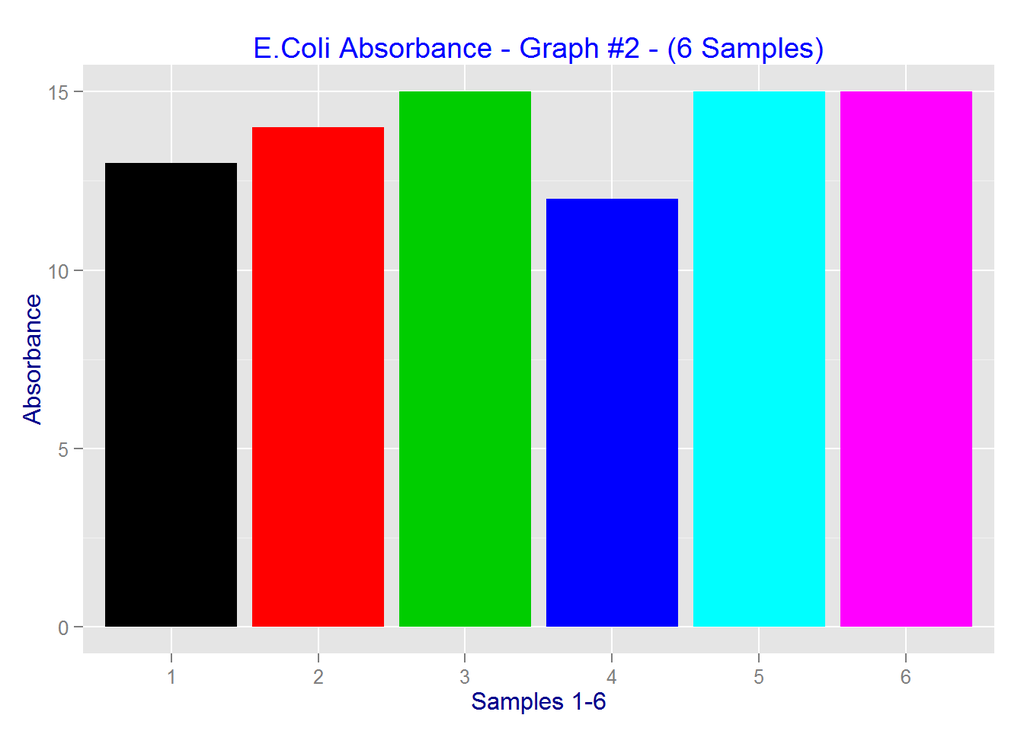

```r
rLine <- coef(lm(data2$Material~data2$Absorbance_E_Coli, data=data2))
layout(matrix(1,1,1))
ggplot(data2, aes(x=as.factor(data2$Material),
                        y=data2$Absorbance_E_Coli)) +
geom_bar(aes(), stat="identity", fill=data2$Material) +
ggtitle("E.Coli Absorbance - Graph #2 - (6 Samples)") +
xlab("Samples 1-6") + ylab("Absorbance") +
theme(plot.title=element_text(color="blue")) +
theme(axis.title=element_text(color="darkblue")) +
geom_abline(intercept=rLine[1], slope=rLine[2], col="#008000")
```

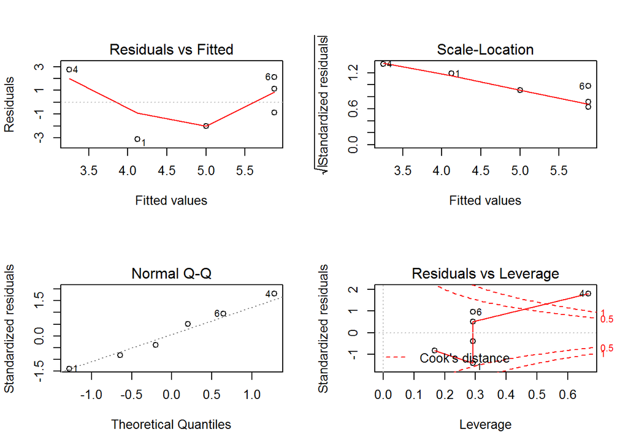

```r
fit <- lm(as.numeric(data2$Material)~data2$Absorbance_E_Coli, na.rm=T)
layout(matrix(c(1,2,3,4),2,2))
plot(fit)
```

### Graph 2 - E.Coli Linear Regression Plots:

1. Residuals vs. Fitted - the shape of the plot shows a linear relationship in the six data points of the E.Coli Graph #2 data.
2. Normal Q-Q - shows the data points all corresponding with the theoritical quantities. Thereby, demonstrating accuracy of the Linear Regression, and the predictive ability of the data in E.Coli Graph #2.
3. Scale-Location - demonstrates equal distribution of residuals along the range of predictors, with all of the data points showing linearity.
4. Residuals vs Leverage - demonstrates there are influential cases within the E.Coli Graph #2 data, via the Cook’s distance line being within the graph. The specific influential data points are data points 4 and 6.

```r
cor.test(as.numeric(data2$Material), data2$Absorbance_E_Coli,
         method="spearman")
```

```
##
##  Spearman's rank correlation rho
##
## data:  as.numeric(data2$Material) and data2$Absorbance_E_Coli
## S = 16.936, p-value = 0.2946
## alternative hypothesis: true rho is not equal to 0
## sample estimates:
##       rho
## 0.5161002
```

### Graph 2 - E. Coli - Spearman’s Rank Correlation:

The E.Coli Graph #2 data points do not demonstrate reliability as predictors. The Spearman’s Rank, or rho, never equals 0, and the Null Hypothesis isn’t supported. Data within the Graph #2 data has possible use for response prediction, as demonstrated by the Linear Regression above.

```r
t.test(as.numeric(data2$Material), data2$Absorbance_E_Coli)
```

```
##
##  Welch Two Sample t-test
##
## data:  as.numeric(data2$Material) and data2$Absorbance_E_Coli
## t = -7.6064, df = 7.2295, p-value = 0.0001065
## alternative hypothesis: true difference in means is not equal to 0
## 95 percent confidence interval:
##  -11.779956  -6.220044
## sample estimates:
## mean of x mean of y
##         5        14
```

### Graph 2 - E. Coli - T-Test:

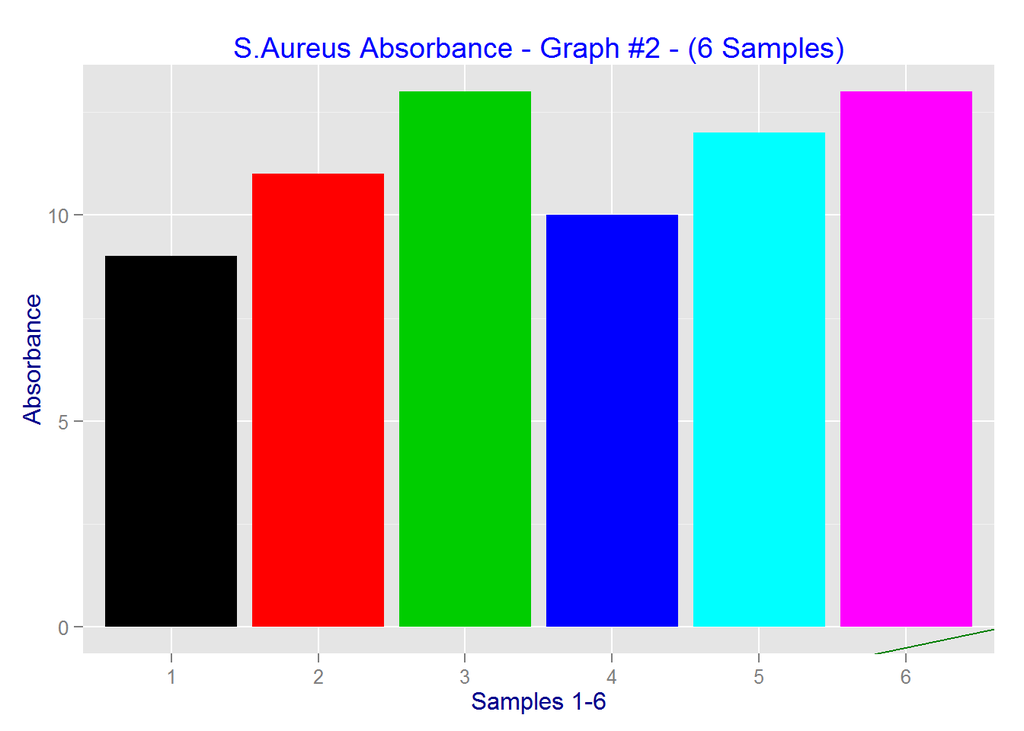

```r
rLine <- coef(lm(data2$Material~data2$Absorbance_S_Aureus, data=data2))
layout(matrix(1,1,1))
ggplot(data2, aes(x=as.factor(data2$Material),
                        y=data2$Absorbance_S_Aureus)) +
geom_bar(aes(), stat="identity", fill=data2$Material) +
ggtitle("S.Aureus Absorbance - Graph #2 - (6 Samples)") +
xlab("Samples 1-6") + ylab("Absorbance") +
theme(plot.title=element_text(color="blue")) +
theme(axis.title=element_text(color="darkblue")) +
geom_abline(intercept=rLine[1], slope=rLine[2], col="#008000")
```

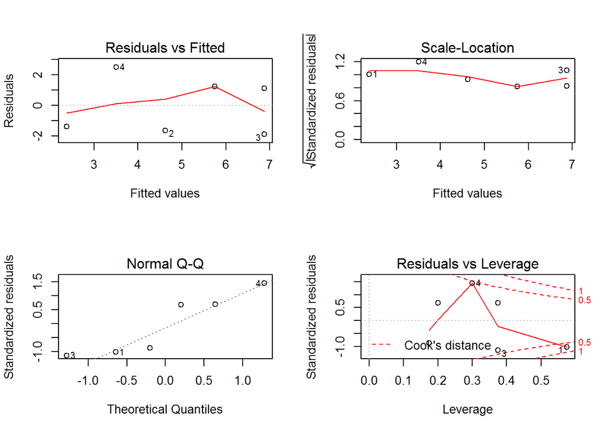

```r
fit <- lm(as.numeric(data2$Material)~data2$Absorbance_S_Aureus, na.rm=T)
layout(matrix(c(1,2,3,4),2,2))
plot(fit)
```

### Graph 2 - S.Aureus - Linear Regression Plots:

1. Residuals vs. Fitted - there is a non-linear relationship in the six data points of the S.Aureus Graph #2 data.
2. Normal Q-Q - the data points aren’t in exact correspondence with the theoritical quantities. Accuracy of the Linear Regression, and the predictive ability of the data in S.Aureus Graph #2, isn’t demostrated.
3. Scale-Location - demonstrates equal distribution of residuals along the range of predictors, with all of the data points showing linearity.
4. Residuals vs Leverage - demonstrates there are influential cases within the S.Aureus Graph #2 data, via the Cook’s distance line being within the graph. The specific influential data points are data points 1 and 4.

```r
cor.test(as.numeric(data2$Material), data2$Absorbance_S_Aureus,
         method="spearman")
```

```
##
##  Spearman's rank correlation rho
##
## data:  as.numeric(data2$Material) and data2$Absorbance_S_Aureus
## S = 12.679, p-value = 0.1731
## alternative hypothesis: true rho is not equal to 0
## sample estimates:
##       rho
## 0.6377481
```

### Graph 2 - S.Aureus - Spearman’s Rank Correlation:

According to the Spearman’s Rank Correlation, the S.Aureus Graph #2 data points do not demonstrate reliability as predictors. However, the Spearman’s Rank, or rho, never equals 0, and the Null Hypothesis isn’t supported.

```r
t.test(as.numeric(data2$Material), data2$Absorbance_S_Aureus)
```

```
##
##  Welch Two Sample t-test
##
## data:  as.numeric(data2$Material) and data2$Absorbance_S_Aureus
## t = -5.0421, df = 8.3989, p-value = 0.0008618
## alternative hypothesis: true difference in means is not equal to 0
## 95 percent confidence interval:
##  -9.206126 -3.460540
## sample estimates:
## mean of x mean of y
##   5.00000  11.33333
```

### Graph 2 - S.Aureus - T-Test:

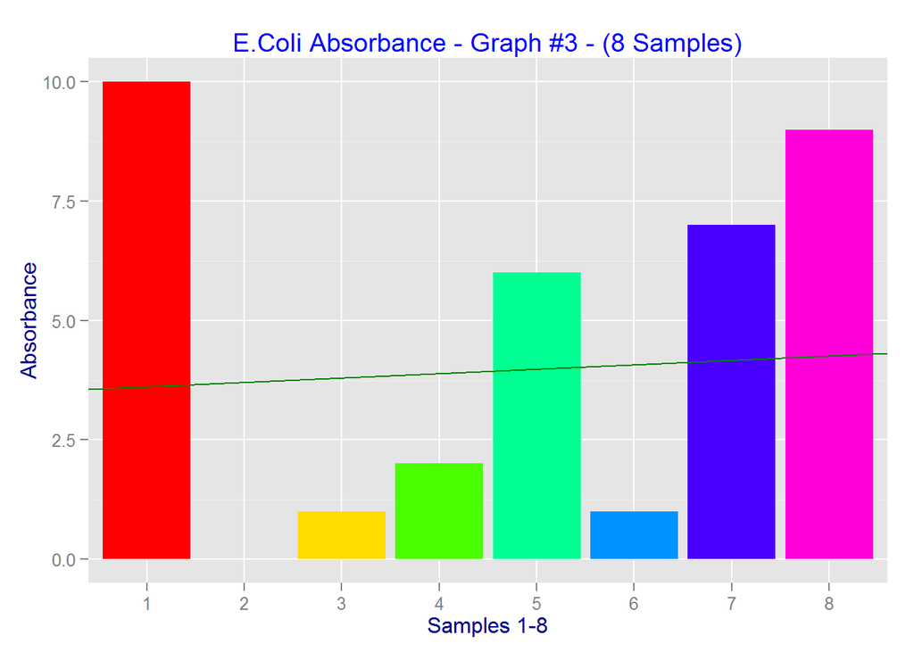

```r
data3$Material[1] <- "1"; data3$Material[2] <- "2"
rLine <- coef(lm(data3$Material~data3$Absorbance_E_Coli, data=data3))
layout(matrix(1,1,1))
ggplot(data3, aes(x=as.factor(data3$Material),
                        y=data3$Absorbance_E_Coli)) +
geom_bar(aes(), stat="identity", fill=rainbow(7)) +
ggtitle("E.Coli Absorbance - Graph #3 - (8 Samples)") +
xlab("Samples 1-8") + ylab("Absorbance") +
theme(plot.title=element_text(color="blue")) +
theme(axis.title=element_text(color="darkblue")) +
geom_abline(intercept=rLine[1], slope=rLine[2], col="#008000")
```

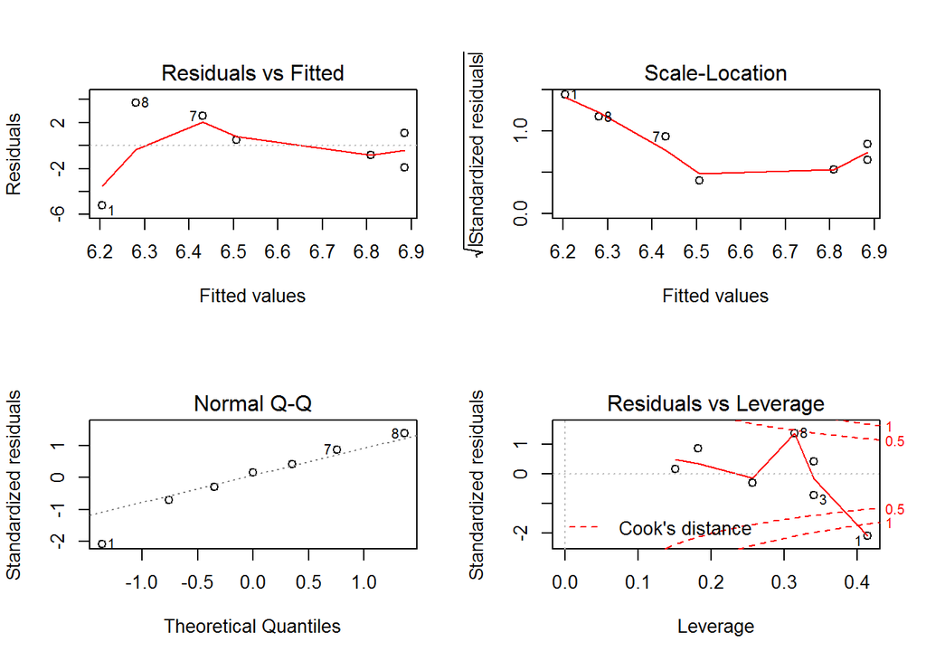

```r
fit <- lm(as.numeric(data3$Material)~data3$Absorbance_E_Coli, na.rm=T)
layout(matrix(c(1,2,3,4),2,2))
plot(fit)
```

### Graph 3 - E.Coli - Linear Regression Plots:

1. Residuals vs. Fitted - the shape of the plot doesn’t show a linear relationship in the eight data points of the E.Coli Graph #3 data.
2. Normal Q-Q - shows the data points mostly corresponding with the theoritical quantities. Thereby, demonstrating accuracy of the Linear Regression, and the predictive ability of the data in E.Coli Graph #3.
3. Scale-Location - demonstrates almost equal distribution of residuals along the range of predictors. A lack of linearity still exists.
4. Residuals vs Leverage - demonstrates there are influential cases within the E.Coli Graph #3 data, via the Cook’s distance line being within the graph. The specific influential data points are data points 3 and 8.

```r
cor.test(as.numeric(data3$Material), data3$Absorbance_E_Coli,
         method="spearman")
```

```
##
##  Spearman's rank correlation rho
##
## data:  as.numeric(data3$Material) and data3$Absorbance_E_Coli
## S = 50.955, p-value = 0.8477
## alternative hypothesis: true rho is not equal to 0
## sample estimates:
##        rho
## 0.09009375
```

### Graph 3 - E.Coli - Spearman’s Rank Correlation:

According to the test statistic, and the P-Value, the Graph #3 data points do not demonstrate reliability as predictors. The Spearman’s Rank, or rho, never equals 0, and the Null Hypothesis isn’t supported. The Linear Regression above demonstrates that the E.Coli Graph #3 data has possible use for response prediction.

```r
t.test(as.numeric(data3$Material), data3$Absorbance_E_Coli)
```

```
##
##  Welch Two Sample t-test
##
## data:  as.numeric(data3$Material) and data3$Absorbance_E_Coli
## t = 0.54677, df = 11.509, p-value = 0.595
## alternative hypothesis: true difference in means is not equal to 0
## 95 percent confidence interval:
##  -2.950132  4.914418
## sample estimates:
## mean of x mean of y
##  6.125000  5.142857
```

### Graph 3 - E.Coli - T-Test:

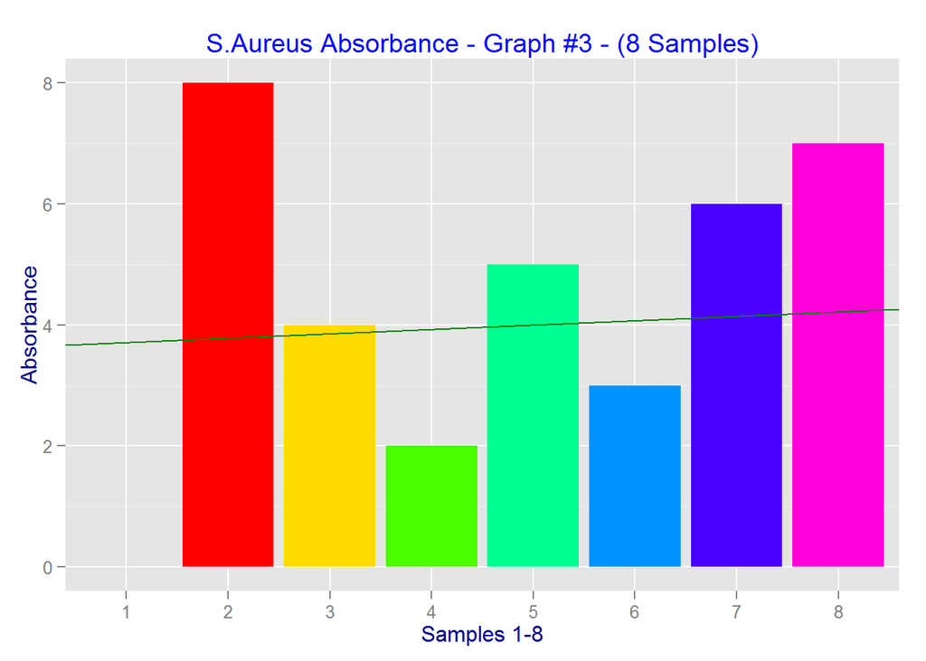

```r
rLine <- coef(lm(data3$Material~data3$Absorbance_S_Aureus, data=data3))
layout(matrix(1,1,1))
ggplot(data3, aes(x=as.factor(data3$Material),
                        y=data3$Absorbance_S_Aureus)) +
geom_bar(aes(), stat="identity", fill=rainbow(7)) +
ggtitle("S.Aureus Absorbance - Graph #3 - (8 Samples)") +
xlab("Samples 1-8") + ylab("Absorbance") +
theme(plot.title=element_text(color="blue")) +
theme(axis.title=element_text(color="darkblue")) +
geom_abline(intercept=rLine[1], slope=rLine[2], col="#008000")
```

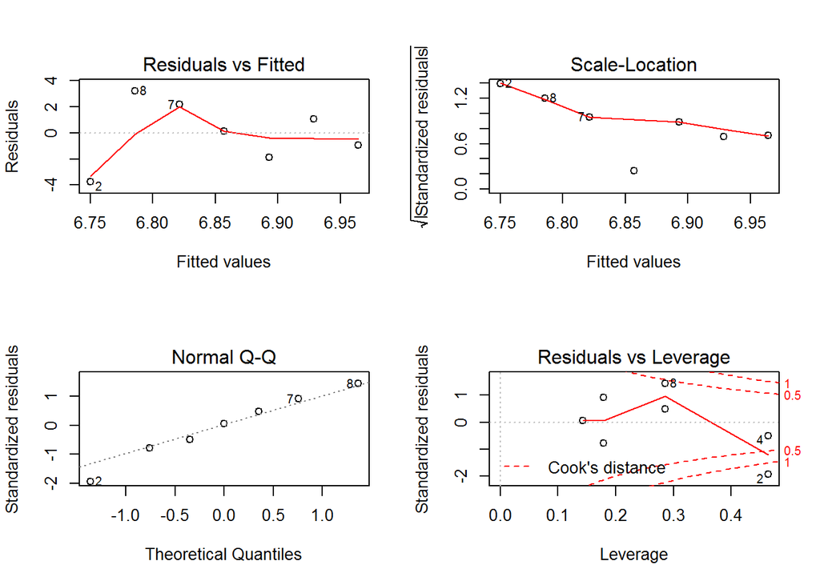

```r
fit <- lm(as.numeric(data3$Material)~data3$Absorbance_S_Aureus, na.rm=T)
layout(matrix(c(1,2,3,4),2,2))
plot(fit)
```

### Graph 3 - S.Aureus - Linear Regression Plots:

```r
cor.test(as.numeric(data3$Material), data3$Absorbance_S_Aureus,
         method="spearman")
```

```
##
##  Spearman's rank correlation rho
##
## data:  as.numeric(data3$Material) and data3$Absorbance_S_Aureus
## S = 52, p-value = 0.9063
## alternative hypothesis: true rho is not equal to 0
## sample estimates:
##        rho
## 0.07142857
```

### Graph 3 - S.Aureus - Spearman’s Rank Correlation:

The S.Aureus Graph #3 data points do not demonstrate reliability as predictors.

```r
t.test(as.numeric(data3$Material), data3$Absorbance_S_Aureus)
```

```
##
##  Welch Two Sample t-test
##
## data:  as.numeric(data3$Material) and data3$Absorbance_S_Aureus
## t = 0.83273, df = 12.533, p-value = 0.4206
## alternative hypothesis: true difference in means is not equal to 0
## 95 percent confidence interval:
##  -1.804719  4.054719
## sample estimates:
## mean of x mean of y
##     6.125     5.000
```